# Chapter 4: Clustering and classification

## Data

Loading the data and having some look of the main principles.

```r
library(dplyr)
```

```r
library(ggplot2)
library(tidyr)
library(boot)
library(MASS)
library(corrplot)
data(Boston)
head(Boston)
```

```
##      crim zn indus chas   nox    rm  age    dis rad tax ptratio  black lstat
## 1 0.00632 18  2.31    0 0.538 6.575 65.2 4.0900   1 296    15.3 396.90  4.98
## 2 0.02731  0  7.07    0 0.469 6.421 78.9 4.9671   2 242    17.8 396.90  9.14
## 3 0.02729  0  7.07    0 0.469 7.185 61.1 4.9671   2 242    17.8 392.83  4.03
## 4 0.03237  0  2.18    0 0.458 6.998 45.8 6.0622   3 222    18.7 394.63  2.94
## 5 0.06905  0  2.18    0 0.458 7.147 54.2 6.0622   3 222    18.7 396.90  5.33
## 6 0.02985  0  2.18    0 0.458 6.430 58.7 6.0622   3 222    18.7 394.12  5.21
##   medv
## 1 24.0
## 2 21.6
## 3 34.7
## 4 33.4
## 5 36.2
## 6 28.7
```

```r
dim(Boston)
```

```
## [1] 506  14
```

This boston data set is contains 506 observations in 14 following variables:

crim = per capita crime rate by town.

zn = proportion of residential land zoned for lots over 25,000 sq.ft.

indus = proportion of non-retail business acres per town.

chas = Charles River dummy variable (= 1 if tract bounds river; 0 otherwise).

nox = nitrogen oxides concentration (parts per 10 million).

rm = average number of rooms per dwelling.

age = proportion of owner-occupied units built prior to 1940.

dis = weighted mean of distances to five Boston employment centres.

rad = index of accessibility to radial highways.

tax = full-value property-tax rate per $10,000.

ptratio = pupil-teacher ratio by town.

black = 1000(Bk - 0.63)^2 where Bk is the proportion of blacks by town.

lstat = lower status of the population (percent).

medv = median value of owner-occupied homes in $1000s.

Here is numerical and graphical abstract of the data.

```r
summary(Boston)
```

```
##       crim                zn             indus            chas
##  Min.   : 0.00632   Min.   :  0.00   Min.   : 0.46   Min.   :0.00000
##  1st Qu.: 0.08205   1st Qu.:  0.00   1st Qu.: 5.19   1st Qu.:0.00000
##  Median : 0.25651   Median :  0.00   Median : 9.69   Median :0.00000
##  Mean   : 3.61352   Mean   : 11.36   Mean   :11.14   Mean   :0.06917
##  3rd Qu.: 3.67708   3rd Qu.: 12.50   3rd Qu.:18.10   3rd Qu.:0.00000
##  Max.   :88.97620   Max.   :100.00   Max.   :27.74   Max.   :1.00000
##       nox               rm             age              dis
##  Min.   :0.3850   Min.   :3.561   Min.   :  2.90   Min.   : 1.130
##  1st Qu.:0.4490   1st Qu.:5.886   1st Qu.: 45.02   1st Qu.: 2.100
##  Median :0.5380   Median :6.208   Median : 77.50   Median : 3.207
##  Mean   :0.5547   Mean   :6.285   Mean   : 68.57   Mean   : 3.795
##  3rd Qu.:0.6240   3rd Qu.:6.623   3rd Qu.: 94.08   3rd Qu.: 5.188
##  Max.   :0.8710   Max.   :8.780   Max.   :100.00   Max.   :12.127
##       rad              tax           ptratio          black
##  Min.   : 1.000   Min.   :187.0   Min.   :12.60   Min.   :  0.32
##  1st Qu.: 4.000   1st Qu.:279.0   1st Qu.:17.40   1st Qu.:375.38
##  Median : 5.000   Median :330.0   Median :19.05   Median :391.44
##  Mean   : 9.549   Mean   :408.2   Mean   :18.46   Mean   :356.67
##  3rd Qu.:24.000   3rd Qu.:666.0   3rd Qu.:20.20   3rd Qu.:396.23
##  Max.   :24.000   Max.   :711.0   Max.   :22.00   Max.   :396.90
##      lstat            medv
##  Min.   : 1.73   Min.   : 5.00
##  1st Qu.: 6.95   1st Qu.:17.02
##  Median :11.36   Median :21.20
##  Mean   :12.65   Mean   :22.53
##  3rd Qu.:16.95   3rd Qu.:25.00
##  Max.   :37.97   Max.   :50.00
```

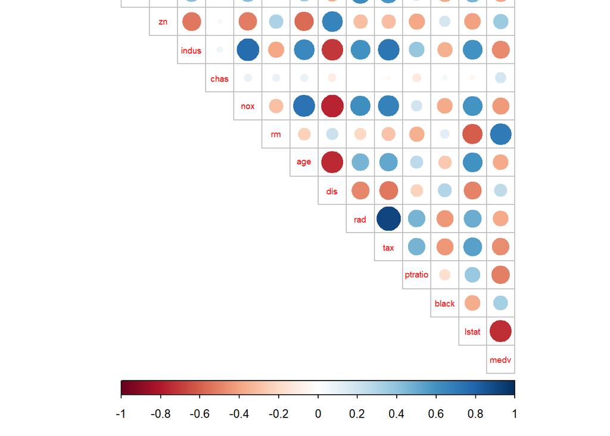

```r
cor_matrix <- cor(Boston) %>% round(digits = 2)
corrplot(cor_matrix, method="circle", type="upper", cl.pos="b", tl.pos="d", tl.cex = 0.6)
```

Visual overview show strong negative correlation between:

*lower status of the population (percent) and median value of owner-occupied homes in $1000s* proportion of owner-occupied units built prior to 1940 and weighted mean of distances to five Boston employment centres *proportion of non-retail business acres per town and weighted mean of distances to five Boston employment centres

These correlations make sense. For example, it is evident that buildings that are old are closer to employment centers.

Additionaly there are strong positive correlation between:

*index of accessibility to radial highways and full-value property-tax rate per $10,000* proportion of non-retail business acres per town and nitrogen oxides concentration (parts per 10 million)

These correlations are also evident. The high way access indicate higher property tax rate and industry provide some NO emissions.

Back to top

## Scaling

```r
boston_scaled <- scale(Boston)
boston_scaled <- as.data.frame(boston_scaled)
summary(boston_scaled)
```

```
##       crim                 zn               indus              chas
##  Min.   :-0.419367   Min.   :-0.48724   Min.   :-1.5563   Min.   :-0.2723
##  1st Qu.:-0.410563   1st Qu.:-0.48724   1st Qu.:-0.8668   1st Qu.:-0.2723
##  Median :-0.390280   Median :-0.48724   Median :-0.2109   Median :-0.2723
##  Mean   : 0.000000   Mean   : 0.00000   Mean   : 0.0000   Mean   : 0.0000
##  3rd Qu.: 0.007389   3rd Qu.: 0.04872   3rd Qu.: 1.0150   3rd Qu.:-0.2723
##  Max.   : 9.924110   Max.   : 3.80047   Max.   : 2.4202   Max.   : 3.6648
##       nox                rm               age               dis
##  Min.   :-1.4644   Min.   :-3.8764   Min.   :-2.3331   Min.   :-1.2658
##  1st Qu.:-0.9121   1st Qu.:-0.5681   1st Qu.:-0.8366   1st Qu.:-0.8049
##  Median :-0.1441   Median :-0.1084   Median : 0.3171   Median :-0.2790
##  Mean   : 0.0000   Mean   : 0.0000   Mean   : 0.0000   Mean   : 0.0000
##  3rd Qu.: 0.5981   3rd Qu.: 0.4823   3rd Qu.: 0.9059   3rd Qu.: 0.6617
##  Max.   : 2.7296   Max.   : 3.5515   Max.   : 1.1164   Max.   : 3.9566
##       rad               tax             ptratio            black
##  Min.   :-0.9819   Min.   :-1.3127   Min.   :-2.7047   Min.   :-3.9033
##  1st Qu.:-0.6373   1st Qu.:-0.7668   1st Qu.:-0.4876   1st Qu.: 0.2049
##  Median :-0.5225   Median :-0.4642   Median : 0.2746   Median : 0.3808
##  Mean   : 0.0000   Mean   : 0.0000   Mean   : 0.0000   Mean   : 0.0000
##  3rd Qu.: 1.6596   3rd Qu.: 1.5294   3rd Qu.: 0.8058   3rd Qu.: 0.4332
##  Max.   : 1.6596   Max.   : 1.7964   Max.   : 1.6372   Max.   : 0.4406
##      lstat              medv
##  Min.   :-1.5296   Min.   :-1.9063
##  1st Qu.:-0.7986   1st Qu.:-0.5989
##  Median :-0.1811   Median :-0.1449
##  Mean   : 0.0000   Mean   : 0.0000
##  3rd Qu.: 0.6024   3rd Qu.: 0.2683
##  Max.   : 3.5453   Max.   : 2.9865
```

```r
quant <- quantile(boston_scaled$crim)
crim <- cut(boston_scaled$crim, breaks = quant, include.lowest = TRUE, labels = c("low","med_low","med_high","high"))
boston_scaled <- dplyr::select(boston_scaled, -crim)
boston_scaled <- cbind(boston_scaled, crim)

# Creating training and testing sets
n <- nrow(boston_scaled)
ind <- sample(n,  size = n * 0.8)
training <- boston_scaled[ind,]
testing <- boston_scaled[-ind,]
```

Back to top

## Fit the linear discriminant

```r
ldamod <- lda(crim ~ ., data = training)
ldamod
```

```
## Call:
## lda(crim ~ ., data = training)
##
## Prior probabilities of groups:
##       low   med_low  med_high      high
## 0.2648515 0.2599010 0.2400990 0.2351485
##
## Group means:
##                   zn      indus        chas        nox          rm        age
## low       0.85297087 -0.8964626 -0.08835242 -0.8484270  0.44357682 -0.8627744
## med_low  -0.07786562 -0.3138416 -0.08484810 -0.5962841 -0.13288563 -0.3884669
## med_high -0.39706559  0.1439655  0.17414622  0.3323429  0.01366708  0.3731760
## high     -0.48724019  1.0172655 -0.02367011  1.0695461 -0.42040215  0.8207434
##                 dis        rad        tax     ptratio      black       lstat
## low       0.8144425 -0.6952911 -0.7485179 -0.43100562  0.3813717 -0.76614669
## med_low   0.4371520 -0.5454537 -0.4893031 -0.09295748  0.3218286 -0.15132023
## med_high -0.3246202 -0.4313174 -0.3320878 -0.17708004  0.1254482  0.03560484
## high     -0.8597078  1.6366336  1.5129868  0.77903654 -0.8229048  0.84500041
##                  medv
## low       0.531241706
## med_low   0.005959781
## med_high  0.100230773
## high     -0.640838562
##
## Coefficients of linear discriminants:
##                  LD1          LD2         LD3
## zn       0.123667401  0.711909334 -0.96712479
## indus   -0.001008838 -0.247110800  0.42916826
## chas    -0.021476244 -0.033865819 -0.02140033
## nox      0.437190715 -0.770226232 -1.38016239
## rm       0.020155569 -0.001476908 -0.22862775
## age      0.230629435 -0.313961169 -0.03580667
## dis     -0.088807335 -0.365993694  0.43221236
## rad      3.248155472  1.044998626  0.04156539
## tax      0.117409462 -0.070329101  0.57189803
## ptratio  0.152773335 -0.030637062 -0.38772364
## black   -0.134525256  0.049343445  0.09917898
## lstat    0.254265353 -0.270531450  0.35950129
## medv     0.142389174 -0.414690102 -0.09095194
##
## Proportion of trace:
##    LD1    LD2    LD3
## 0.9581 0.0298 0.0121
```

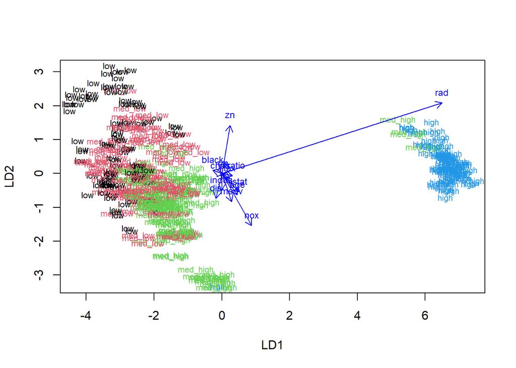

```r
lda.arrows <- function(x, myscale = 1, arrow_heads = 0.1, color = "blue", tex = 0.75, choices = c(1,2)){
  heads <- coef(x)
  arrows(x0 = 0, y0 = 0,
         x1 = myscale * heads[,choices[1]],
         y1 = myscale * heads[,choices[2]], col=color, length = arrow_heads)
  text(myscale * heads[,choices], labels = row.names(heads),
       cex = tex, col=color, pos=3)
}

classes <- as.numeric(training$crim)

plot(ldamod, dimen = 2, col = classes, pch = classes)
lda.arrows(ldamod, myscale = 2)
```